# Museum Art Collections Exploratory Analysis

Author

Zixu Hao

Published

April 3, 2025

# Introduction

This analysis explores four museum art collection datasets: 1. Cleveland Museum of Art (`cleveland_art_museum.csv`) 2. Metropolitan Museum of Art (`Met_objects.csv`) 3. MoMA Artists (`Moma_Artists.csv`) 4. MoMA Artworks (`Moma_Artworks.csv`)

These datasets contain rich information about artworks, artists, creation dates, materials, and dimensions. Our EDA aims to:

- Understand basic statistical characteristics of each collection
- Examine artist nationality and gender distributions
- Analyze temporal patterns in artwork creation
- Compare materials and mediums across collections
- Identify unique characteristics of each museum’s collection

# Methodology

Our approach includes:

1. **Data Loading & Initial Inspection**: Structure and missing values
2. **Univariate Analysis**: Distribution of key variables
3. **Bivariate Analysis**: Relationships between variables
4. **Cross-Collection Comparison**: Identifying unique patterns
5. **Visualization**: Effective graphical representations

## Technical Options

Choose either Python or R for the analysis:

```python
# Python setup
import pandas as pd
import numpy as np
import matplotlib.pyplot as plt
import seaborn as sns
```

```r
# R setup
library(tidyverse)
library(lubridate)
library(scales)
library(ggridges)
library(patchwork)
```

# Data Analysis

1. Data Loading (Python Option)

```python
# Load all datasets
cleveland = pd.read_csv("../data/cleveland_art_museum.csv")
met = pd.read_csv("../data/Met_objects.csv")
moma_artists = pd.read_csv("../data/Moma_Artists.csv")
moma_artworks = pd.read_csv("../data/Moma_Artworks.csv")

# Display structure
print("Cleveland Museum:")
```

```
Cleveland Museum:
```

```python
print(cleveland.head(2))
```

```
      id  ...                  updated_at
0  74228  ...  2025-02-08 21:57:34.713000
1  74539  ...  2025-02-08 21:57:35.217000

[2 rows x 45 columns]
```

```python
print("\nMet Museum:")
```

```
Met Museum:
```

```python
print(met.head(2))
```

```
  Object Number  Is Highlight  ...  Tags AAT URL  Tags Wikidata URL
0    1979.486.1         False  ...           NaN                NaN
1    1980.264.5         False  ...           NaN                NaN

[2 rows x 54 columns]
```

```python
print("\nMoMA Artists:")
```

```
MoMA Artists:
```

```python
print(moma_artists.head(2))
```

```
   ConstituentID     DisplayName            ArtistBio  ... EndDate Wiki QID  ULAN
0              1  Robert Arneson  American, 1930–1992  ...    1992      NaN   NaN
1              2  Doroteo Arnaiz   Spanish, born 1936  ...       0      NaN   NaN

[2 rows x 9 columns]
```

```python
print("\nMoMA Artworks:")
```

```
MoMA Artworks:
```

```python
print(moma_artworks.head(2))
```

```
                                               Title  ... Duration (sec.)
0  Ferdinandsbrücke Project, Vienna, Austria (Ele...  ...             NaN
1  City of Music, National Superior Conservatory ...  ...             NaN

[2 rows x 30 columns]
```

1. Data Loading (R Option)

```r
# Load all datasets
cleveland <- read_csv("../data/cleveland_art_museum.csv")
met <- read_csv("../data/Met_objects.csv")
moma_artists <- read_csv("../data/Moma_Artists.csv")
moma_artworks <- read_csv("../data/Moma_Artworks.csv")
# Display structure
glimpse(cleveland)
```

```
Rows: 67,908
Columns: 45
$ id                          <dbl> 74228, 74539, 74540, 74551, 74553, 74554, …
$ accession_number            <chr> "2020.113", "2015.449", "2015.451", "2018.…
$ share_license_status        <chr> "CC0", "CC0", "CC0", "CC0", "CC0", "CC0", …
$ tombstone                   <chr> "Fishmarket, 1902. Camille Pissarro (Frenc…
$ current_location            <chr> NA, NA, NA, NA, NA, NA, NA, NA, NA, NA, NA…
$ title                       <chr> "Fishmarket", "A Miller's Carriage", "Leda…
$ title_in_original_language  <chr> NA, NA, NA, NA, NA, NA, NA, NA, NA, NA, NA…
$ series                      <chr> NA, NA, NA, NA, NA, NA, NA, NA, NA, NA, NA…
$ series_in_original_language <chr> NA, NA, NA, NA, NA, NA, NA, NA, NA, NA, NA…
$ creation_date               <chr> "1902", "c. 1895", "c. 1846–83", "c. 1802–…
$ creation_date_earliest      <dbl> 1902, 1890, 1834, 1797, 1865, 1843, 1800, …
$ creation_date_latest        <dbl> 1902, 1900, 1893, 1835, 1885, 1853, 1899, …
$ artists_tags                <chr> "['Jewish artists', 'male']", "['male']", …
```

[output cut: 32 more lines]

```r
glimpse(met)
```

```
Rows: 484,956
Columns: 54
$ `Object Number`           <chr> "1979.486.1", "1980.264.5", "67.265.9", "67.…
$ `Is Highlight`            <lgl> FALSE, FALSE, FALSE, FALSE, FALSE, FALSE, FA…
$ `Is Timeline Work`        <lgl> FALSE, FALSE, FALSE, FALSE, FALSE, FALSE, FA…
$ `Is Public Domain`        <lgl> FALSE, FALSE, FALSE, FALSE, FALSE, FALSE, FA…
$ `Object ID`               <dbl> 1, 2, 3, 4, 5, 6, 7, 8, 9, 10, 11, 12, 13, 1…
$ `Gallery Number`          <chr> NA, NA, NA, NA, NA, NA, NA, NA, NA, NA, NA, …
$ Department                <chr> "The American Wing", "The American Wing", "T…
$ AccessionYear             <dbl> 1979, 1980, 1967, 1967, 1967, 1967, 1967, 19…
$ `Object Name`             <chr> "Coin", "Coin", "Coin", "Coin", "Coin", "Coi…
$ Title                     <chr> "One-dollar Liberty Head Coin", "Ten-dollar …
$ Culture                   <chr> NA, NA, NA, NA, NA, NA, NA, NA, NA, NA, NA, …
$ Period                    <chr> NA, NA, NA, NA, NA, NA, NA, NA, NA, NA, NA, …
$ Dynasty                   <chr> NA, NA, NA, NA, NA, NA, NA, NA, NA, NA, NA, …
```

[output cut: 41 more lines]

```r
glimpse(moma_artists)
```

```
Rows: 15,648
Columns: 9
$ ConstituentID <dbl> 1, 2, 3, 4, 5, 6, 7, 9, 10, 11, 12, 13, 15, 16, 18, 19, …
$ DisplayName   <chr> "Robert Arneson", "Doroteo Arnaiz", "Bill Arnold", "Char…
$ ArtistBio     <chr> "American, 1930–1992", "Spanish, born 1936", "American, …
$ Nationality   <chr> "American", "Spanish", "American", "American", "Danish",…
$ Gender        <chr> "male", "male", "male", "male", "male", "male", "male", …
$ BeginDate     <dbl> 1930, 1936, 1941, 1946, 1941, 1925, 1941, 1923, 1918, 18…
$ EndDate       <dbl> 1992, 0, 0, 0, 0, 0, 0, 0, 0, 1966, 0, 1995, 1997, 1964,…
$ `Wiki QID`    <chr> NA, NA, NA, "Q1063584", NA, NA, NA, "Q5230870", "Q197485…
$ ULAN          <dbl> NA, NA, NA, 500027998, NA, NA, NA, 500003363, 500042413,…
```

```r
glimpse(moma_artworks)
```

```
Rows: 157,612
Columns: 30
$ Title                <chr> "Ferdinandsbrücke Project, Vienna, Austria (Eleva…
$ Artist               <chr> "Otto Wagner", "Christian de Portzamparc", "Emil …
$ ConstituentID        <chr> "6210", "7470", "7605", "7056", "7605", "7056", "…
$ ArtistBio            <chr> "(Austrian, 1841–1918)", "(French, born 1944)", "…
$ Nationality          <chr> "(Austrian)", "(French)", "(Austrian)", "()", "(A…
$ BeginDate            <chr> "(1841)", "(1944)", "(1876)", "(1944)", "(1876)",…
$ EndDate              <chr> "(1918)", "(0)", "(1957)", "(0)", "(1957)", "(0)"…
$ Gender               <chr> "(male)", "(male)", "(male)", "(male)", "(male)",…
$ Date                 <chr> "1896", "1987", "1903", "1980", "1903", "1976-77"…
$ Medium               <chr> "Ink and cut-and-pasted painted pages on paper", …
$ Dimensions           <chr> "19 1/8 x 66 1/2\" (48.6 x 168.9 cm)", "16 x 11 3…
$ CreditLine           <chr> "Fractional and promised gift of Jo Carole and Ro…
$ AccessionNumber      <chr> "885.1996", "1.1995", "1.1997", "2.1995", "2.1997…
```

[output cut: 17 more lines]

2. Cleveland Museum Analysis (Python)

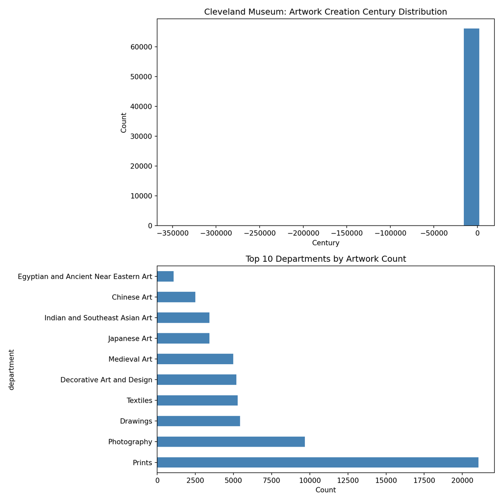

```python
# Basic statistics
cleveland_stats = pd.DataFrame({
    "Total Artworks": [len(cleveland)],
    "Unique Artists": [cleveland["artists_tags"].nunique()],
    "Earliest Work": [cleveland["creation_date_earliest"].min()],
    "Latest Work": [cleveland["creation_date_latest"].max()]
})

# Department distribution
dept_counts = cleveland["department"].value_counts().head(10)

# Visualization
fig, (ax1, ax2) = plt.subplots(2, 1, figsize=(10, 10))

# Time distribution
cleveland["century"] = (cleveland["creation_date_earliest"] // 100) * 100
ax1.hist(cleveland["century"].dropna(), bins=20, color="steelblue")
ax1.set_title("Cleveland Museum: Artwork Creation Century Distribution")
ax1.set_xlabel("Century")
ax1.set_ylabel("Count")

# Department distribution
dept_counts.plot(kind="barh", ax=ax2, color="steelblue")
ax2.set_title("Top 10 Departments by Artwork Count")
ax2.set_xlabel("Count")

plt.tight_layout()
plt.show()
```

2. Cleveland Museum Analysis (R)

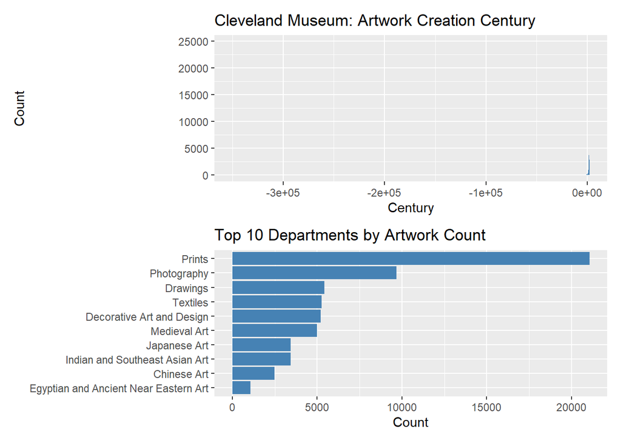

```r
# Basic statistics
cleveland_summary <- cleveland %>%
  summarise(
    n_artworks = n(),
    n_artists = n_distinct(artists_tags),
    earliest_year = min(creation_date_earliest, na.rm = TRUE),
    latest_year = max(creation_date_latest, na.rm = TRUE)
  )

# Department distribution
cleveland_dept <- cleveland %>%
  count(department, sort = TRUE) %>%
  head(10)

# Time distribution
cleveland_time <- cleveland %>%
  filter(!is.na(creation_date_earliest)) %>%
  mutate(century = floor(creation_date_earliest/100)*100)

# Visualization
p1 <- ggplot(cleveland_time, aes(x = century)) +
  geom_histogram(binwidth = 100, fill = "steelblue") +
  labs(title = "Cleveland Museum: Artwork Creation Century",
       x = "Century", y = "Count")

p2 <- ggplot(cleveland_dept, aes(x = reorder(department, n), y = n)) +
  geom_col(fill = "steelblue") +
  coord_flip() +
  labs(title = "Top 10 Departments by Artwork Count",
       x = "", y = "Count")

p1 / p2
```

3. Metropolitan Museum Analysis (Python)

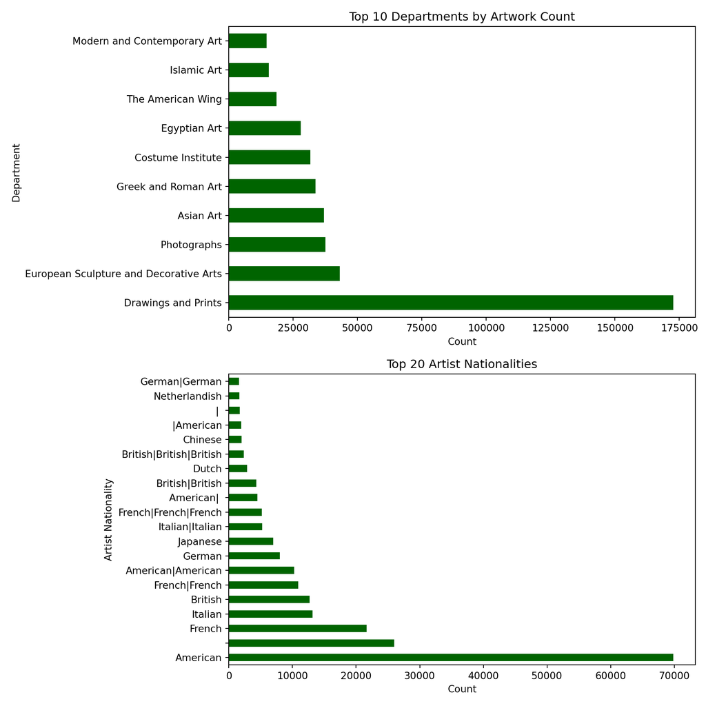

```python
# Basic statistics
met_stats = pd.DataFrame({
    "Total Artworks": [len(met)],
    "Unique Artists": [met["Artist Display Name"].nunique()],
    "Departments": [met["Department"].nunique()],
    "Earliest Work": [met["Object Begin Date"].min()],
    "Latest Work": [met["Object End Date"].max()]
})

# Nationality analysis
nationality_counts = met["Artist Nationality"].value_counts().head(20)

# Visualization
fig, (ax1, ax2) = plt.subplots(2, 1, figsize=(10, 10))

# Department distribution
met["Department"].value_counts().head(10).plot(kind="barh", ax=ax1, color="darkgreen")
ax1.set_title("Top 10 Departments by Artwork Count")
ax1.set_xlabel("Count")

# Nationality distribution
nationality_counts.plot(kind="barh", ax=ax2, color="darkgreen")
ax2.set_title("Top 20 Artist Nationalities")
ax2.set_xlabel("Count")

plt.tight_layout()
plt.show()
```

3. Metropolitan Museum Analysis (R)

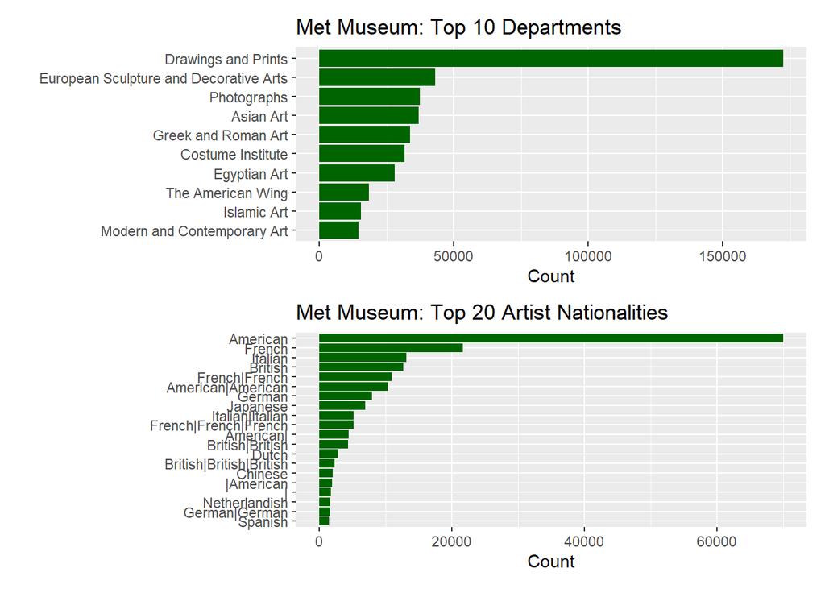

```r
# Basic statistics
met_summary <- met %>%
  summarise(
    n_artworks = n(),
    n_artists = n_distinct(`Artist Display Name`),
    n_departments = n_distinct(Department),
    earliest_year = min(`Object Begin Date`, na.rm = TRUE),
    latest_year = max(`Object End Date`, na.rm = TRUE)
  )

# Department distribution
met_dept <- met %>%
  count(Department, sort = TRUE) %>%
  head(10)

# Nationality analysis
met_nationality <- met %>%
  filter(!is.na(`Artist Nationality`)) %>%
  count(`Artist Nationality`, sort = TRUE) %>%
  head(20)

# Visualization
p3 <- ggplot(met_dept, aes(x = reorder(Department, n), y = n)) +
  geom_col(fill = "darkgreen") +
  coord_flip() +
  labs(title = "Met Museum: Top 10 Departments",
       x = "", y = "Count")

p4 <- ggplot(met_nationality, aes(x = reorder(`Artist Nationality`, n), y = n)) +
  geom_col(fill = "darkgreen") +
  coord_flip() +
  labs(title = "Met Museum: Top 20 Artist Nationalities",
       x = "", y = "Count")

p3 + p4 + plot_layout(ncol = 1)
```

4. MoMA Analysis (Python)

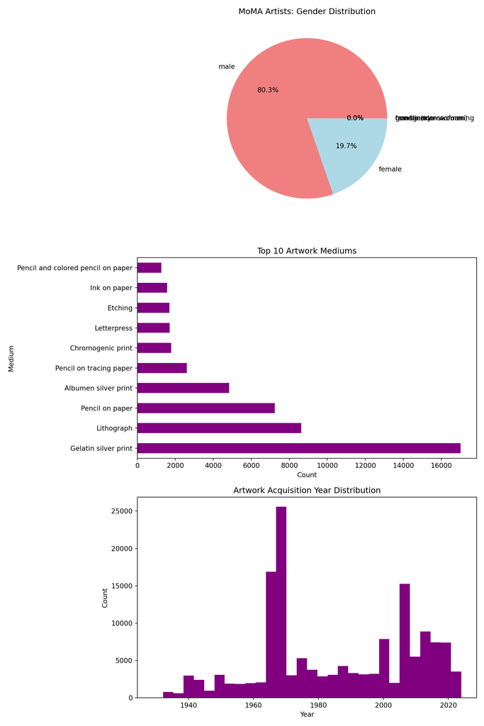

```python
# Gender distribution
gender_dist = moma_artists["Gender"].value_counts(normalize=True)

# Medium analysis
medium_dist = moma_artworks["Medium"].value_counts().head(20)

# Visualization
fig, (ax1, ax2, ax3) = plt.subplots(3, 1, figsize=(10, 15))

# Gender pie chart
gender_dist.plot(kind="pie", autopct="%1.1f%%", ax=ax1, colors=["lightcoral", "lightblue"])
ax1.set_title("MoMA Artists: Gender Distribution")
ax1.set_ylabel("")

# Medium distribution
medium_dist.head(10).plot(kind="barh", ax=ax2, color="purple")
ax2.set_title("Top 10 Artwork Mediums")
ax2.set_xlabel("Count")

# Acquisition year
moma_artworks["AcquisitionYear"] = pd.to_datetime(moma_artworks["DateAcquired"]).dt.year
ax3.hist(moma_artworks["AcquisitionYear"].dropna(), bins=30, color="purple")
ax3.set_title("Artwork Acquisition Year Distribution")
ax3.set_xlabel("Year")
ax3.set_ylabel("Count")

plt.tight_layout()
plt.show()
```

4. MoMA Analysis (R)

[figure not shown]

```r
# Gender distribution
gender_dist <- moma_artists %>%
  filter(!is.na(Gender)) %>%
  count(Gender) %>%
  mutate(percent = n/sum(n))

# Medium analysis
medium_dist <- moma_artworks %>%
  filter(!is.na(Medium)) %>%
  count(Medium, sort = TRUE) %>%
  head(20)

# Acquisition year
moma_acquisition <- moma_artworks %>%
  mutate(year_acquired = year(mdy(DateAcquired))) %>%
  filter(!is.na(year_acquired))
# Visualization
p5 <- ggplot(gender_dist, aes(x = "", y = percent, fill = Gender)) +
  geom_bar(stat = "identity") +
  coord_polar("y") +
  labs(title = "MoMA Artists: Gender Distribution") +
  scale_fill_brewer(palette = "Pastel1")

p6 <- ggplot(medium_dist %>% head(10), aes(x = reorder(Medium, n), y = n)) +
  geom_col(fill = "purple") +
  coord_flip() +
  labs(title = "Top 10 Artwork Mediums",
       x = "", y = "Count")

p7 <- ggplot(moma_acquisition, aes(x = year_acquired)) +
  geom_histogram(binwidth = 5, fill = "purple") +
  labs(title = "Artwork Acquisition Year Distribution",
       x = "Year", y = "Count")

(p5 + p6) / p7 + plot_layout(heights = c(1, 2))
```

5. Cross-Museum Comparison (Python)

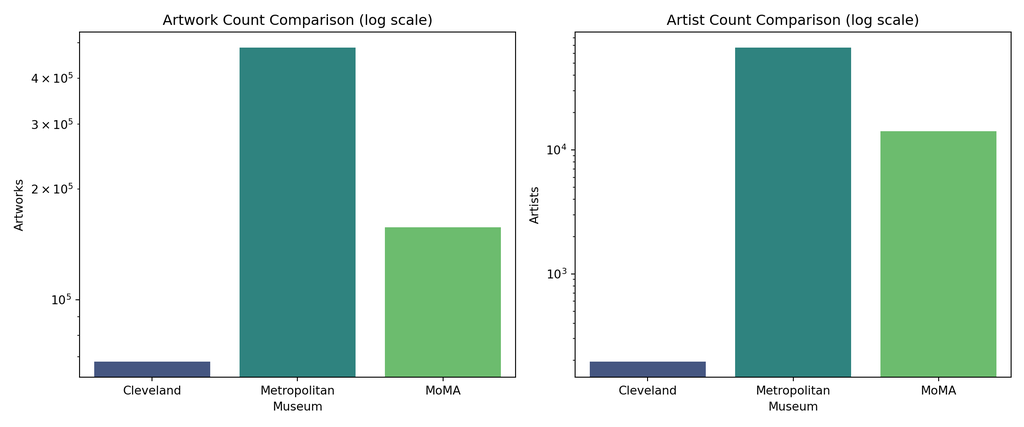

```python
# Create comparison dataframe
comparison = pd.DataFrame({
    "Museum": ["Cleveland", "Metropolitan", "MoMA"],
    "Artworks": [len(cleveland), len(met), len(moma_artworks)],
    "Artists": [cleveland["artists_tags"].nunique(),
                met["Artist Display Name"].nunique(),
                moma_artworks["ConstituentID"].nunique()]
})

# Visualization
fig, (ax1, ax2) = plt.subplots(1, 2, figsize=(12, 5))

# Artworks comparison
sns.barplot(data=comparison, x="Museum", y="Artworks", palette="viridis", ax=ax1)
ax1.set_yscale("log")
ax1.set_title("Artwork Count Comparison (log scale)")

# Artists comparison
sns.barplot(data=comparison, x="Museum", y="Artists", palette="viridis", ax=ax2)
ax2.set_yscale("log")
ax2.set_title("Artist Count Comparison (log scale)")

plt.tight_layout()
plt.show()
```

5. Cross-Museum Comparison (R)

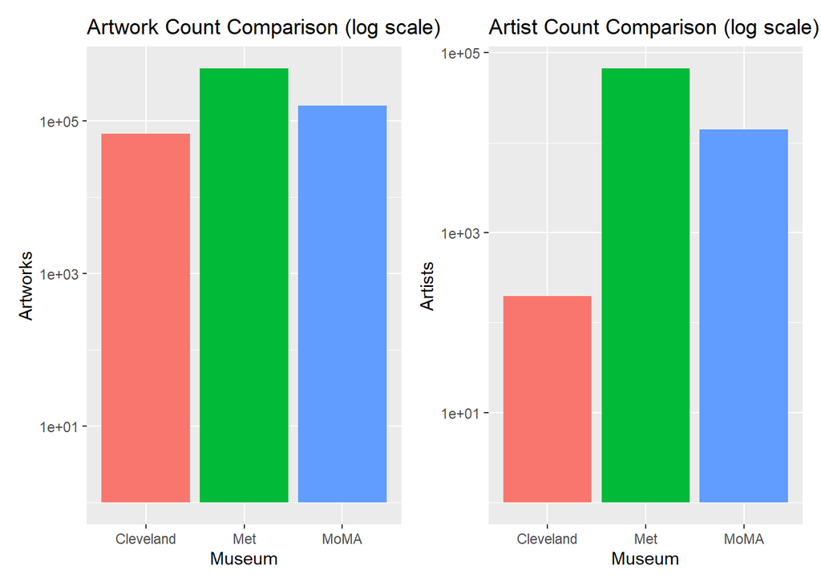

```r
# Create comparison data
museum_comparison <- tribble(
  ~Museum, ~Artworks, ~Artists,
  "Cleveland", nrow(cleveland), n_distinct(cleveland$artists_tags),
  "Met", nrow(met), n_distinct(met$`Artist Display Name`),
  "MoMA", nrow(moma_artworks), n_distinct(moma_artworks$ConstituentID)
)

# Visualization
p8 <- ggplot(museum_comparison, aes(x = Museum, y = Artworks, fill = Museum)) +
  geom_col() +
  scale_y_log10() +
  labs(title = "Artwork Count Comparison (log scale)") +
  theme(legend.position = "none")

p9 <- ggplot(museum_comparison, aes(x = Museum, y = Artists, fill = Museum)) +
  geom_col() +
  scale_y_log10() +
  labs(title = "Artist Count Comparison (log scale)") +
  theme(legend.position = "none")

p8 + p9
```

# Key Findings

- Collection Size:

  Metropolitan Museum has the largest collection (both artworks and artists)

  Cleveland and MoMA have more specialized collections
- Temporal Patterns:

  Cleveland and Met contain ancient to contemporary works

  MoMA focuses primarily on modern and contemporary art
- Artist Diversity:

  Met shows greatest nationality diversity

  MoMA specializes in modern mediums (photography, prints)

# Limitations & Next Steps

- Data Quality Issues:

  Missing values in key fields

  Inconsistent formatting across collections
- Analysis Opportunities:

  Text analysis of artwork titles/descriptions

  Network analysis of artist collaborations

  Geographic mapping of artwork origins
- Comparative Studies:

  Deeper comparison of acquisition policies

  Exhibition history analysis

  Conservation state comparisons